# ALS: Data Validation Report (R2004471.zip)

Zachary M. Smith

2020-07-27

# Results

## Summary

**Goal:** Summary of data validation results.

**Issues:**

- **EDP Error Summary:** There are 0 records in the Error Table
- **Distinct Rows Check:** 0 Failures
- **Schema Check:** 19 Failures
- **Site Check:**
  - **Field:** 13 Failures
  - **Lab:** 20 Failures
- **Value Check:** 2207 Failures

# Overview of `ALS_Results`

**Overview**

Table Overview

| Columns | 66 |
| --- | --- |
| Rows | 321 |
| `NA`s | 9499 (44.8%) |
| Duplicate Rows | 0 |

Column Types

| character | 29 |
| --- | --- |
| logical | 18 |
| numeric | 11 |
| integer | 8 |

**Reproducibility**

Reproducibility Information

| Scan Build Time | `2020-07-27 16:21:09` |
| --- | --- |
| **pointblank** Version | `0.4.0` |
| **R** Version | R version 4.0.2 (2020–06–22) *Taking Off Again* |
| Operating System | `x86_64-w64-mingw32` |

## EDP Error Summary (ALS)

*The content below was provided by ALS*

## EDP Error Summary

There are 0 records in the Error Table

User Name: joni.janson

Format Name: Sample_v3, TestResultQC_v3, Batch_v3

Format Version: 3.00.29

EDD File(s):  
R:/eddge/client files/NYSDEC Equis v3 RIBS/R2004471/Sample_v3.txt  
R:/eddge/client files/NYSDEC Equis v3 RIBS/R2004471/TestResultQC_v3.txt  
R:/eddge/client files/NYSDEC Equis v3 RIBS/R2004471/Batch_v3.txt

RefVals Set: C:/Program Files/EarthSoft/EQuIS/Formats/NYS DEC v3/NYSDEC.rvf

Run Date: 6/23/2020 6:38:40 PM

| Table | # of Rows | Column | Value | Message | Type |
| --- | --- | --- | --- | --- | --- |

## Distinct Rows Check

**Goal:** Identify if any rows in the provided data table are duplicated.

Pointblank Validation

`agent_2020-07-27_16:20:58 (2020-07-27 16:20:58)`

|  | STEP | COLUMNS | VALUES | TBL | EVAL | UNITS | PASS | FAIL | W | S | N | EXT |
| --- | --- | --- | --- | --- | --- | --- | --- | --- | --- | --- | --- | --- |
| 1 | rows_distinct | ▮X.sys_sample_code, ▮lab_anl_method_name, ▮analysis_date, ▮fraction, ▮column_number, ▮test_type, ▮lab_matrix_code, ▮analysis_location, ▮basis, ▮container_id, ▮dilution_factor, ▮prep_method, ▮prep_date… | — |  |  | `321` | `321` `1.00` | `0` `0.00` | — | — | — | — |

## Schema Check

**Goal:** Identify if the data table provided meets the expected data schema, which represents a check on the name, order, and data type (e.g., character, numeric, integer) of the supplied columns.

Pointblank Validation

`agent_2020-07-27_16:20:58 (2020-07-27 16:21:00)`

|  | STEP | COLUMNS | VALUES | TBL | EVAL | UNITS | PASS | FAIL | W | S | N | EXT |
| --- | --- | --- | --- | --- | --- | --- | --- | --- | --- | --- | --- | --- |
| 1 | col_schema_match | — | SCHEMA R TYPES |  |  | `1` | `0` `0.00` | `1` `1.00` | — | — | — | — |
| 2 | col_exists | ▮X.sys_sample_code | — |  |  | `1` | `1` `1.00` | `0` `0.00` | — | — | — | — |
| 3 | col_exists | ▮lab_anl_method_name | — |  |  | `1` | `1` `1.00` | `0` `0.00` | — | — | — | — |
| 4 | col_exists | ▮analysis_date | — |  |  | `1` | `1` `1.00` | `0` `0.00` | — | — | — | — |
| 5 | col_exists | ▮fraction | — |  |  | `1` | `1` `1.00` | `0` `0.00` | — | — | — | — |
| 6 | col_exists | ▮column_number | — |  |  | `1` | `1` `1.00` | `0` `0.00` | — | — | — | — |
| 7 | col_exists | ▮test_type | — |  |  | `1` | `1` `1.00` | `0` `0.00` | — | — | — | — |
| 8 | col_exists | ▮lab_matrix_code | — |  |  | `1` | `1` `1.00` | `0` `0.00` | — | — | — | — |
| 9 | col_exists | ▮analysis_location | — |  |  | `1` | `1` `1.00` | `0` `0.00` | — | — | — | — |
| 10 | col_exists | ▮basis | — |  |  | `1` | `1` `1.00` | `0` `0.00` | — | — | — | — |
| 11 | col_exists | ▮container_id | — |  |  | `1` | `1` `1.00` | `0` `0.00` | — | — | — | — |
| 12 | col_exists | ▮dilution_factor | — |  |  | `1` | `1` `1.00` | `0` `0.00` | — | — | — | — |
| 13 | col_exists | ▮prep_method | — |  |  | `1` | `1` `1.00` | `0` `0.00` | — | — | — | — |
| 14 | col_exists | ▮prep_date | — |  |  | `1` | `1` `1.00` | `0` `0.00` | — | — | — | — |
| 15 | col_exists | ▮leachate_method | — |  |  | `1` | `1` `1.00` | `0` `0.00` | — | — | — | — |
| 16 | col_exists | ▮leachate_date | — |  |  | `1` | `1` `1.00` | `0` `0.00` | — | — | — | — |
| 17 | col_exists | ▮lab_name_code | — |  |  | `1` | `1` `1.00` | `0` `0.00` | — | — | — | — |
| 18 | col_exists | ▮qc_level | — |  |  | `1` | `1` `1.00` | `0` `0.00` | — | — | — | — |
| 19 | col_exists | ▮lab_sample_id | — |  |  | `1` | `1` `1.00` | `0` `0.00` | — | — | — | — |
| 20 | col_exists | ▮percent_moisture | — |  |  | `1` | `1` `1.00` | `0` `0.00` | — | — | — | — |
| 21 | col_exists | ▮subsample_amount | — |  |  | `1` | `1` `1.00` | `0` `0.00` | — | — | — | — |
| 22 | col_exists | ▮subsample_amount_unit | — |  |  | `1` | `1` `1.00` | `0` `0.00` | — | — | — | — |
| 23 | col_exists | ▮analyst_name | — |  |  | `1` | `1` `1.00` | `0` `0.00` | — | — | — | — |
| 24 | col_exists | ▮instrument_id | — |  |  | `1` | `1` `1.00` | `0` `0.00` | — | — | — | — |
| 25 | col_exists | ▮comment | — |  |  | `1` | `1` `1.00` | `0` `0.00` | — | — | — | — |
| 26 | col_exists | ▮preservative | — |  |  | `1` | `1` `1.00` | `0` `0.00` | — | — | — | — |
| 27 | col_exists | ▮final_volume | — |  |  | `1` | `1` `1.00` | `0` `0.00` | — | — | — | — |
| 28 | col_exists | ▮final_volume_unit | — |  |  | `1` | `1` `1.00` | `0` `0.00` | — | — | — | — |
| 29 | col_exists | ▮cas_rn | — |  |  | `1` | `1` `1.00` | `0` `0.00` | — | — | — | — |
| 30 | col_exists | ▮chemical_name | — |  |  | `1` | `1` `1.00` | `0` `0.00` | — | — | — | — |

[output cut: 103 more lines]

## Site Check

### Expected Field Sites

Pointblank Validation

`agent_2020-07-27_16:21:06 (2020-07-27 16:21:06)`

|  | STEP | COLUMNS | VALUES | TBL | EVAL | UNITS | PASS | FAIL | W | S | N | EXT |
| --- | --- | --- | --- | --- | --- | --- | --- | --- | --- | --- | --- | --- |
| 1 | col_vals_in_set | ▮sys_loc_code | 01-BEAM-0.1, 01-BELS-2.7, 01-BELS_T5-0.6, 01-BERG-1.3, 01-BEVC-1.1, 01-BIND-1.9, 01-BLAS-0.1, 01-BLKE-0.1, 01-BMAN-0.3, 01-BOUR-0.4, 01-BOWE-5.2, 01-BROC-0.1, 01-BSIS-2.0, 01-BSIS-8.6, 01-BSIS-11.4, 0… |  |  | `13` | `0` `0.00` | `13` `1.00` | — | — | — |  |

### Expected Lab Sites

Pointblank Validation

`agent_2020-07-27_16:21:06 (2020-07-27 16:21:06)`

|  | STEP | COLUMNS | VALUES | TBL | EVAL | UNITS | PASS | FAIL | W | S | N | EXT |
| --- | --- | --- | --- | --- | --- | --- | --- | --- | --- | --- | --- | --- |
| 1 | col_vals_in_set | ▮sys_loc_code | 01-BEAM-0.1, 01-BELS-2.7, 01-BELS_T5-0.6, 01-BERG-1.3, 01-BEVC-1.1, 01-BIND-1.9, 01-BLAS-0.1, 01-BLKE-0.1, 01-BMAN-0.3, 01-BOUR-0.4, 01-BOWE-5.2, 01-BROC-0.1, 01-BSIS-2.0, 01-BSIS-8.6, 01-BSIS-11.4, 0… |  |  | `53` | `33` `0.62` | `20` `0.38` | — | — | — |  |

## Value Check

Pointblank Validation

`agent_2020-07-27_16:21:07 (2020-07-27 16:21:07)`

|  | STEP | COLUMNS | VALUES | TBL | EVAL | UNITS | PASS | FAIL | W | S | N | EXT |
| --- | --- | --- | --- | --- | --- | --- | --- | --- | --- | --- | --- | --- |
| 1 | col_vals_in_set | ▮lab_matrix_code | WS, WQ |  |  | `321` | `321` `1.00` | `0` `0.00` | — | — | — | — |
| 2 | col_vals_in_set | ▮fraction | T, D |  |  | `321` | `321` `1.00` | `0` `0.00` | — | — | — | — |
| 3 | col_vals_in_set | ▮test_type | intial, reanalysis |  |  | `321` | `0` `0.00` | `321` `1.00` | — | — | — |  |
| 4 | col_vals_in_set | ▮analysis_location | LB |  |  | `321` | `321` `1.00` | `0` `0.00` | — | — | — | — |
| 5 | col_vals_in_set | ▮prep_method | METHOD, SW3010A, E200.0 |  |  | `321` | `128` `0.40` | `193` `0.60` | — | — | — |  |
| 6 | col_vals_in_set | ▮lab_name_code | ALSRNY |  |  | `321` | `321` `1.00` | `0` `0.00` | — | — | — | — |
| 7 | col_vals_in_set | ▮qc_level | quant |  |  | `321` | `321` `1.00` | `0` `0.00` | — | — | — | — |
| 8 | col_vals_in_set | ▮subsample_amount_unit | mL |  |  | `321` | `321` `1.00` | `0` `0.00` | — | — | — | — |
| 9 | col_vals_in_set | ▮final_volume_unit | mL |  |  | `321` | `247` `0.77` | `74` `0.23` | — | — | — |  |
| 10 | col_vals_in_set | ▮cas_rn | ALK, 7664-41-7, TOC, 16887-00-6, 479-61-8, COLOR, HARD, 14797-55-8, NO3NO2N, 14787-65-0, KN, PHCOLOR, 7723-14-0, 14808-79-8, DOC, UV254, 7440-70-2, 7439-89-6, 7439-95-4, 7439-96-5, 7440-38-2 |  |  | `321` | `304` `0.95` | `17` `0.05` | — | — | — |  |
| 11 | col_vals_in_set | ▮result_type_code | TRG, SC |  |  | `321` | `321` `1.00` | `0` `0.00` | — | — | — | — |
| 12 | col_vals_in_set | ▮reportable_result | Yes |  |  | `321` | `321` `1.00` | `0` `0.00` | — | — | — | — |
| 13 | col_vals_in_set | ▮detect_flag | Y, N |  |  | `321` | `321` `1.00` | `0` `0.00` | — | — | — | — |
| 14 | col_vals_in_set | ▮Lab_qualifiers | U, J |  |  | `321` | `112` `0.35` | `209` `0.65` | — | — | — |  |
| 15 | col_vals_in_set | ▮interpreted_qualifiers | U, J |  |  | `321` | `112` `0.35` | `209` `0.65` | — | — | — |  |
| 16 | col_vals_in_set | ▮Result_unit | mg/l, ug/l, color unit, pH units, 1/cm |  |  | `321` | `321` `1.00` | `0` `0.00` | — | — | — | — |
| 17 | col_vals_in_set | ▮detection_limit_unit | mg/l, ug/l, color unit, pH units, 1/cm |  |  | `321` | `321` `1.00` | `0` `0.00` | — | — | — | — |
| 18 | col_vals_in_set | ▮result_comment | not detected, detected |  |  | `321` | `96` `0.30` | `225` `0.70` | — | — | — |  |
| 19 | col_vals_in_set | ▮qc_spike_status |  |  |  | `321` | `2` `0.01` | `319` `0.99` | — | — | — |  |
| 20 | col_vals_in_set | ▮qc_dup_spike_status |  |  |  | `321` | `1` `0.01` | `320` `0.99` | — | — | — |  |
| 21 | col_vals_in_set | ▮qc_rpd_status |  |  |  | `321` | `1` `0.01` | `320` `0.99` | — | — | — |  |

## Help

The majority of this report makes use of the R-package, [**pointblank**](https://rich-iannone.github.io/pointblank/). **pointblank** provides tools for validating data. Data validation refers to the act of verifying that the data meets expected requirements. For example, **pointblank** can verify that all of the expected columns are present and represent the expected data type (e.g., character, integer, logical, etc.). In this report, the results of the validation process are generally reported in tables generated by the **pointblank** function `interogate()`. The figure below describes how to interpret these tables.

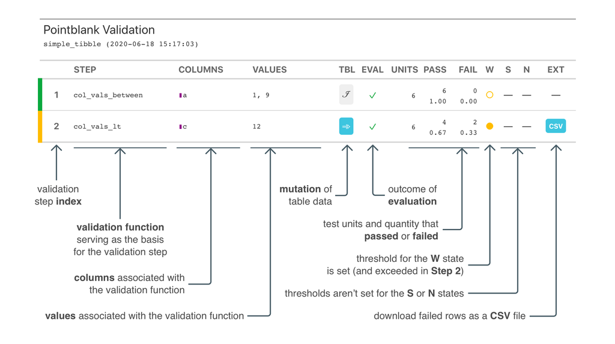

This image provides a description of how to interprate the tables produced by the pointblank R-package. This image is a direct copy of the image provided in the pointblank ‘README.md’ file. Richard Iannone (2020). pointblank: Validation of Local and Remote Data Tables. R package version 0.4.0. https://github.com/rich-iannone/pointblank/blob/master/README.md

**Citation**

Richard Iannone (2020). pointblank: Validation of Local and Remote Data Tables. R package version 0.4.0. https://CRAN.R-project.org/package=pointblank